# HSS8005 - Quantitative analysis

## Fat chance

[figure not shown]

> He threw four knucklebones on to the table and **committed his hopes to the throw**. If he threw well, particularly if he obtained the image of the goddess herself, no two showing the same number, he adored the goddess, and was in high hopes of gratifying his passion; if he threw badly, as usually happens, and got an unlucky combination, he called down imprecations on all Cnidos, and was as much overcome by grief as if he had suffered some personal loss.

> — Lucian of Samosata (c. 125 – 180), writing in his trademark satirical style about a young man who fell in love with Praxiteles’s Aphrodite of Knidos; cited in F. N. David (1955:8)

## Chance with limitations

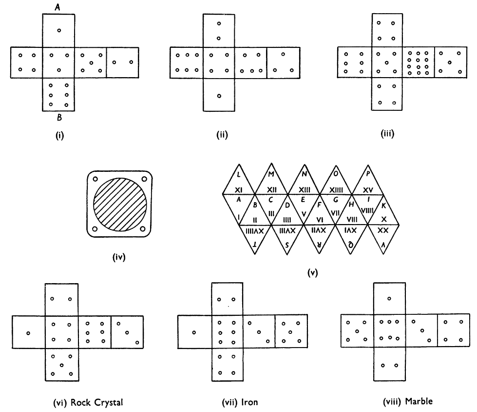

- Dice were sometimes faked. Sometimes numbers were left off or duplicated; hollow dice have been found dating from Roman time
- Dice were also *imperfect*; a fair die was the exception rather than the rule
- Experiment by F. N. David using three dice from the British Museum:

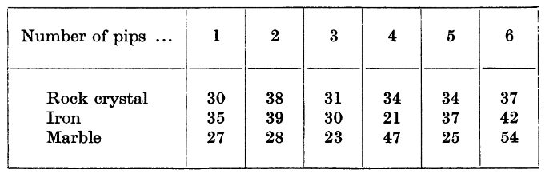